# Reproducible Research: Peer Assessment 1

## Loading and preprocessing the data

Load the data frame containing the activity

```r
#setwd("c:/wb/repdata/RepData_PeerAssessment1")
if (!file.exists("./activity.csv"))
{
  f<- download.file(url = 'http://d396qusza40orc.cloudfront.net/repdata%2Fdata%2Factivity.zip' , destfile = "activity.zip")
  activity.filename <-unzip("./activity.zip")
}
dfActivity <- read.csv ( file = "./activity.csv")
```

## What is mean total number of steps taken per day?

For this part of the assignment, you can ignore the missing values in the dataset. Make a histogram of the total number of steps taken each day

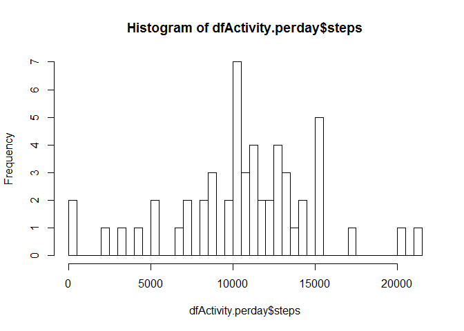

```r
library(reshape)
dfActivity.perday <- aggregate( steps~date, data = dfActivity,FUN  =sum )
hist(dfActivity.perday$steps , breaks = 50 )
```

Calculate and report the mean and median total number of steps taken per day

```r
mean(dfActivity.perday$steps)
```

```
## [1] 10766.19
```

```r
median(dfActivity.perday$steps)
```

```
## [1] 10765
```

## What is the average daily activity pattern?

Make a time series plot (i.e. type = “l”) of the 5-minute interval (x-axis) and the average number of steps taken, averaged across all days (y-axis)

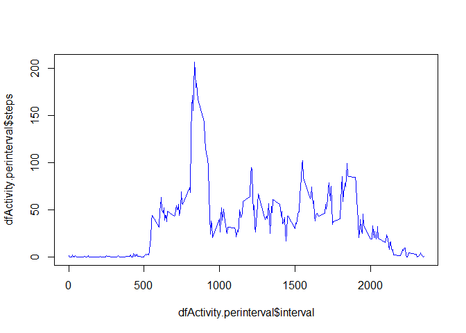

```r
dfActivity.perinterval <- aggregate( steps~interval, data = dfActivity,FUN  =mean)
plot( y=dfActivity.perinterval$steps , x=dfActivity.perinterval$interval , type="l",  col="blue")
```

Which 5-minute interval, on average across all the days in the dataset, contains the maximum number of steps?

```r
maxNumStepsInAInterval       <- max( dfActivity.perinterval$steps )
maxNumStepsInAInterval.index <- match( maxNumStepsInAInterval, dfActivity.perinterval$steps)
tmpi<-dfActivity.perinterval[maxNumStepsInAInterval.index,]
```

The following interval on average has the higest numbr of steps.

```r
tmpi$interval
```

```
## [1] 835
```

```r
tmpi$steps
```

```
## [1] 206.1698
```